# Compound channel hydraulic flume with two longitudinal friction

Felipe

2025-08-19

# Estimation: constant in the main channel and second degree in the floodplain (n_kmin = 0 and n_kflood = 2)

# Experimental set up

A compound channel setup was used for this case study. The paper including all information about the experience was found in [Dupuis et al. (2017)](https://doi.org/10.1007/s10652-017-9525-0).

- Length: 18 m
- Width: 3 m
- Slope: 0.00105
- Main channel: 1 m wide rectangular glass bed
- Floodplain: two 1 m wide rectangular configuration. Both floodplains were covered either by plastic grass alone (meadow) or by an array of emergent cylinders set on the plastic grass (wood).
- Vertical distance from the main channel to the floodplain: 0.115 m
- Flow conditions: uniform flow with a total discharge of 162 L/s, varying the discharge in the floodplain of 12 and 18 L/s.
- Water level measurements: the measures were taken spatial distributed from 2 m to 17 m.

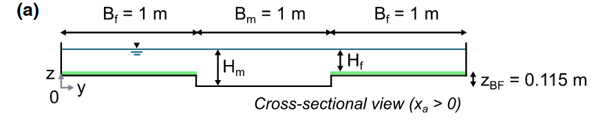

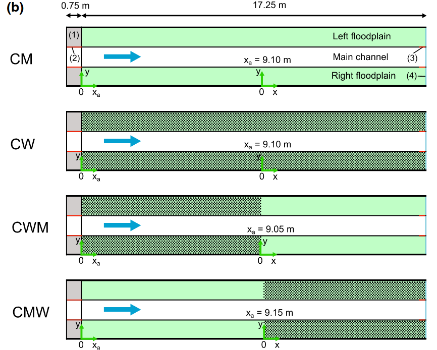

# Objectives and remarks of the case study

- Test the estimation when the friction in the floodplain changes suddenly in longitudinal direction
- Estimate a constant friction in the main channel and a linear combination in the floodplain

# Calibration data

The selected case was a transition from wood to grass. WSE measurements were taken in the main channel and the floodplain at different positions. To compare with the simulations, a single value of WSE was calculated for each position by averaging the WSE values. Then the standard devaition was estimated using all the values for estimating a regression with `lm` function.

| event | reach | x | t | WSE | Discharge | Velocity | Y_Kmin | Y_Kmoy | Yu_z | Yu_Q | Yu_V | Yu_Kmin | Yu_Kmoy |
| --- | --- | --- | --- | --- | --- | --- | --- | --- | --- | --- | --- | --- | --- |
| 1 | 1 | 2.225 | 3420 | 0.1949608 | -9999 | -9999 | -9999 | -9999 | 0.0222257 | -9999 | -9999 | -9999 | -9999 |
| 1 | 1 | 4.310 | 3420 | 0.1880788 | -9999 | -9999 | -9999 | -9999 | 0.0222257 | -9999 | -9999 | -9999 | -9999 |
| 1 | 1 | 5.270 | 3420 | 0.1852095 | -9999 | -9999 | -9999 | -9999 | 0.0222257 | -9999 | -9999 | -9999 | -9999 |
| 1 | 1 | 6.240 | 3420 | 0.1829345 | -9999 | -9999 | -9999 | -9999 | 0.0222257 | -9999 | -9999 | -9999 | -9999 |
| 1 | 1 | 8.315 | 3420 | 0.1767361 | -9999 | -9999 | -9999 | -9999 | 0.0222257 | -9999 | -9999 | -9999 | -9999 |
| 1 | 1 | 9.115 | 3420 | 0.1744950 | -9999 | -9999 | -9999 | -9999 | 0.0222257 | -9999 | -9999 | -9999 | -9999 |
| 1 | 1 | 9.250 | 3420 | 0.1744835 | -9999 | -9999 | -9999 | -9999 | 0.0222257 | -9999 | -9999 | -9999 | -9999 |
| 1 | 1 | 10.250 | 3420 | 0.1737731 | -9999 | -9999 | -9999 | -9999 | 0.0222257 | -9999 | -9999 | -9999 | -9999 |
| 1 | 1 | 11.250 | 3420 | 0.1732561 | -9999 | -9999 | -9999 | -9999 | 0.0222257 | -9999 | -9999 | -9999 | -9999 |
| 1 | 1 | 12.250 | 3420 | 0.1728932 | -9999 | -9999 | -9999 | -9999 | 0.0222257 | -9999 | -9999 | -9999 | -9999 |
| 1 | 1 | 13.250 | 3420 | 0.1729610 | -9999 | -9999 | -9999 | -9999 | 0.0222257 | -9999 | -9999 | -9999 | -9999 |
| 2 | 1 | 2.225 | 3420 | 0.1902885 | -9999 | -9999 | -9999 | -9999 | 0.0222257 | -9999 | -9999 | -9999 | -9999 |
| 2 | 1 | 2.975 | 3420 | 0.1911852 | -9999 | -9999 | -9999 | -9999 | 0.0222257 | -9999 | -9999 | -9999 | -9999 |
| 2 | 1 | 3.345 | 3420 | 0.1892610 | -9999 | -9999 | -9999 | -9999 | 0.0222257 | -9999 | -9999 | -9999 | -9999 |
| 2 | 1 | 4.095 | 3420 | 0.1882043 | -9999 | -9999 | -9999 | -9999 | 0.0222257 | -9999 | -9999 | -9999 | -9999 |
| 2 | 1 | 5.060 | 3420 | 0.1864261 | -9999 | -9999 | -9999 | -9999 | 0.0222257 | -9999 | -9999 | -9999 | -9999 |
| 2 | 1 | 6.240 | 3420 | 0.1797323 | -9999 | -9999 | -9999 | -9999 | 0.0222257 | -9999 | -9999 | -9999 | -9999 |
| 2 | 1 | 6.990 | 3420 | 0.1818093 | -9999 | -9999 | -9999 | -9999 | 0.0222257 | -9999 | -9999 | -9999 | -9999 |
| 2 | 1 | 8.030 | 3420 | 0.1790497 | -9999 | -9999 | -9999 | -9999 | 0.0222257 | -9999 | -9999 | -9999 | -9999 |
| 2 | 1 | 8.795 | 3420 | 0.1743624 | -9999 | -9999 | -9999 | -9999 | 0.0222257 | -9999 | -9999 | -9999 | -9999 |
| 2 | 1 | 9.065 | 3420 | 0.1760431 | -9999 | -9999 | -9999 | -9999 | 0.0222257 | -9999 | -9999 | -9999 | -9999 |
| 2 | 1 | 9.115 | 3420 | 0.1721755 | -9999 | -9999 | -9999 | -9999 | 0.0222257 | -9999 | -9999 | -9999 | -9999 |
| 2 | 1 | 9.545 | 3420 | 0.1748087 | -9999 | -9999 | -9999 | -9999 | 0.0222257 | -9999 | -9999 | -9999 | -9999 |
| 2 | 1 | 10.030 | 3420 | 0.1738211 | -9999 | -9999 | -9999 | -9999 | 0.0222257 | -9999 | -9999 | -9999 | -9999 |
| 2 | 1 | 11.370 | 3420 | 0.1701349 | -9999 | -9999 | -9999 | -9999 | 0.0222257 | -9999 | -9999 | -9999 | -9999 |
| 2 | 1 | 12.120 | 3420 | 0.1723571 | -9999 | -9999 | -9999 | -9999 | 0.0222257 | -9999 | -9999 | -9999 | -9999 |
| 2 | 1 | 12.325 | 3420 | 0.1718688 | -9999 | -9999 | -9999 | -9999 | 0.0222257 | -9999 | -9999 | -9999 | -9999 |
| 2 | 1 | 13.290 | 3420 | 0.1715232 | -9999 | -9999 | -9999 | -9999 | 0.0222257 | -9999 | -9999 | -9999 | -9999 |

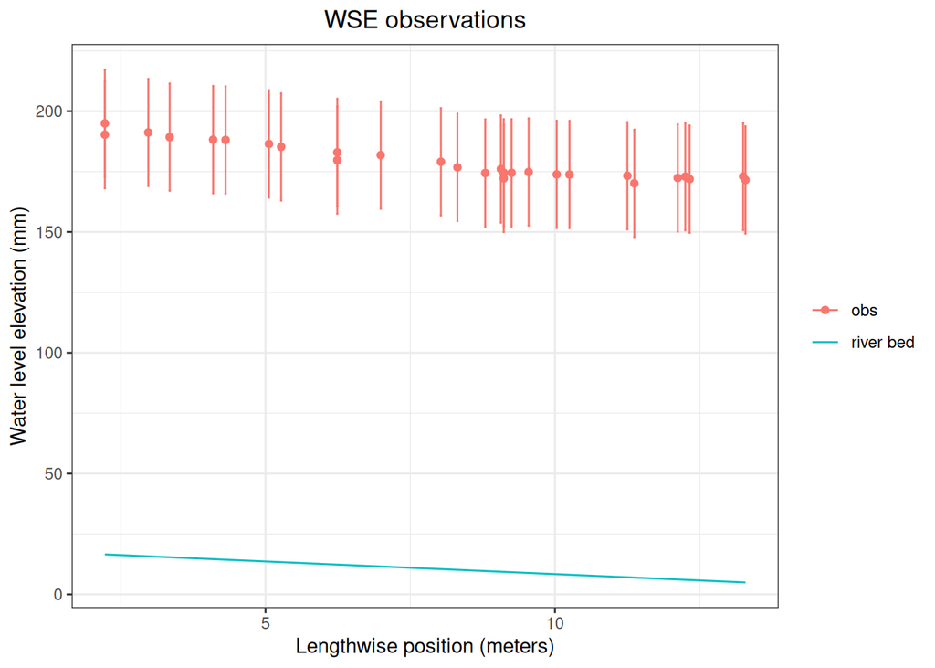

# Estimation with a standard deviation of 22 mm for WSE observations

A constant friction in the main channel and a second degree in the floodplain. Non informative prior were used for all the model’s parameters.

## Check MCMC

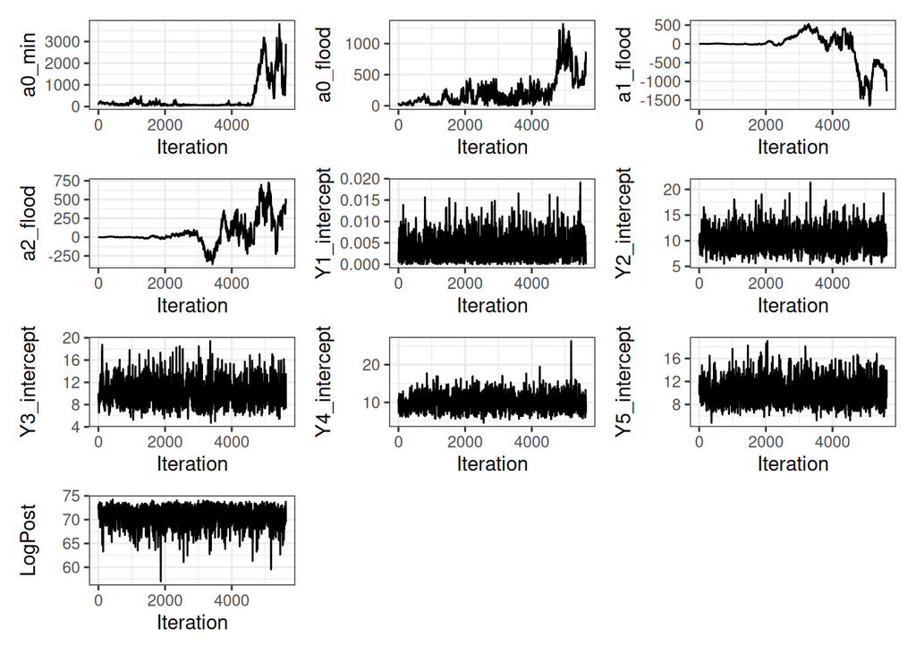

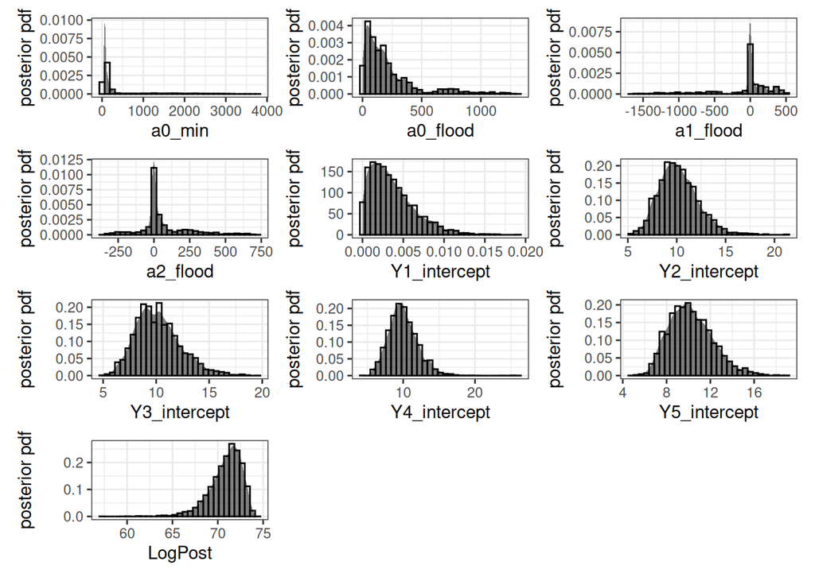

## Check summary

Zoom into the MAP and standard deviation of the error model: WSE in mm, discharge in L/s and velocity in mm/s.

|  | a0_min | a0_flood | a1_flood | a2_flood | Y1_intercept | Y2_intercept | Y3_intercept | Y4_intercept | Y5_intercept |
| --- | --- | --- | --- | --- | --- | --- | --- | --- | --- |
| N | 5.62600e+03 | 5626.00000 | 5626.00000 | 5626.00000 | 5.62600e+03 | 5626.000000 | 5626.000000 | 5626.000000 | 5626.000000 |
| Minimum | 3.55184e+01 | 0.23387 | -1649.16000 | -361.31500 | 5.00000e-07 | 5.409260 | 4.733140 | 4.586530 | 4.809350 |
| Maximum | 3.80910e+03 | 1316.18000 | 529.62900 | 726.81500 | 1.90994e-02 | 21.342000 | 19.417600 | 26.271400 | 19.035800 |
| Range | 3.77358e+03 | 1315.95000 | 2178.79000 | 1088.13000 | 1.90989e-02 | 15.932700 | 14.684500 | 21.684900 | 14.226400 |
| Mean | 3.80925e+02 | 215.93000 | -74.06050 | 59.93410 | 3.64720e-03 | 10.200500 | 10.197200 | 10.006100 | 10.231800 |
| Median | 8.95089e+01 | 144.77400 | 1.12262 | 5.65817 | 3.02540e-03 | 9.996930 | 9.997970 | 9.834780 | 10.058500 |
| Q10% | 5.52200e+01 | 26.66660 | -693.56600 | -85.22800 | 6.35200e-04 | 7.735390 | 7.683250 | 7.567800 | 7.731010 |
| Q25% | 6.64882e+01 | 63.29960 | -19.95560 | -6.18817 | 1.55030e-03 | 8.795520 | 8.674330 | 8.630330 | 8.776950 |
| Q75% | 2.00965e+02 | 263.03100 | 117.53100 | 89.93690 | 5.09150e-03 | 11.421300 | 11.455500 | 11.210800 | 11.522900 |
| Q90% | 1.48642e+03 | 499.93300 | 331.60000 | 299.15600 | 7.51320e-03 | 12.853500 | 13.116400 | 12.572400 | 12.881300 |
| St.Dev. | 6.77711e+02 | 232.48200 | 395.88900 | 172.34800 | 2.75550e-03 | 2.028350 | 2.146470 | 2.064640 | 2.015110 |
| Variance | 4.59292e+05 | 54047.90000 | 156728.00000 | 29703.90000 | 7.60000e-06 | 4.114190 | 4.607330 | 4.262730 | 4.060650 |
| CV | 1.77912e+00 | 1.07665 | 5.34548 | 2.87563 | 7.55499e-01 | 0.198848 | 0.210495 | 0.206337 | 0.196945 |
| Skewness | 2.45334e+00 | 2.04403 | -1.71270 | 1.17837 | 1.13990e+00 | 0.696739 | 0.655586 | 0.852583 | 0.556058 |
| Kurtosis | 5.13545e+00 | 4.22783 | 2.76191 | 2.19167 | 1.44975e+00 | 1.163800 | 0.541119 | 2.926970 | 0.319571 |
| MaxPost | 1.64516e+02 | 9.47946 | 5.31925 | 5.32603 | 1.80120e-03 | 9.848100 | 9.865230 | 9.204450 | 9.287330 |

|  | a0_min | a0_flood | a1_flood | a2_flood | Y1_intercept | Y2_intercept | Y3_intercept | Y4_intercept | Y5_intercept |
| --- | --- | --- | --- | --- | --- | --- | --- | --- | --- |
| St.Dev. | 677.711 | 232.48200 | 395.88900 | 172.34800 | 2.75547 | 2028.35 | 214.647 | 2.06464 | 2.01511 |
| MaxPost | 164.516 | 9.47946 | 5.31925 | 5.32603 | 1.80125 | 9848.10 | 986.523 | 9.20445 | 9.28733 |

## Check spatial friction distribution

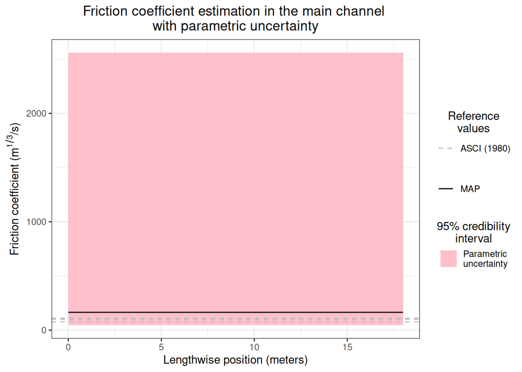

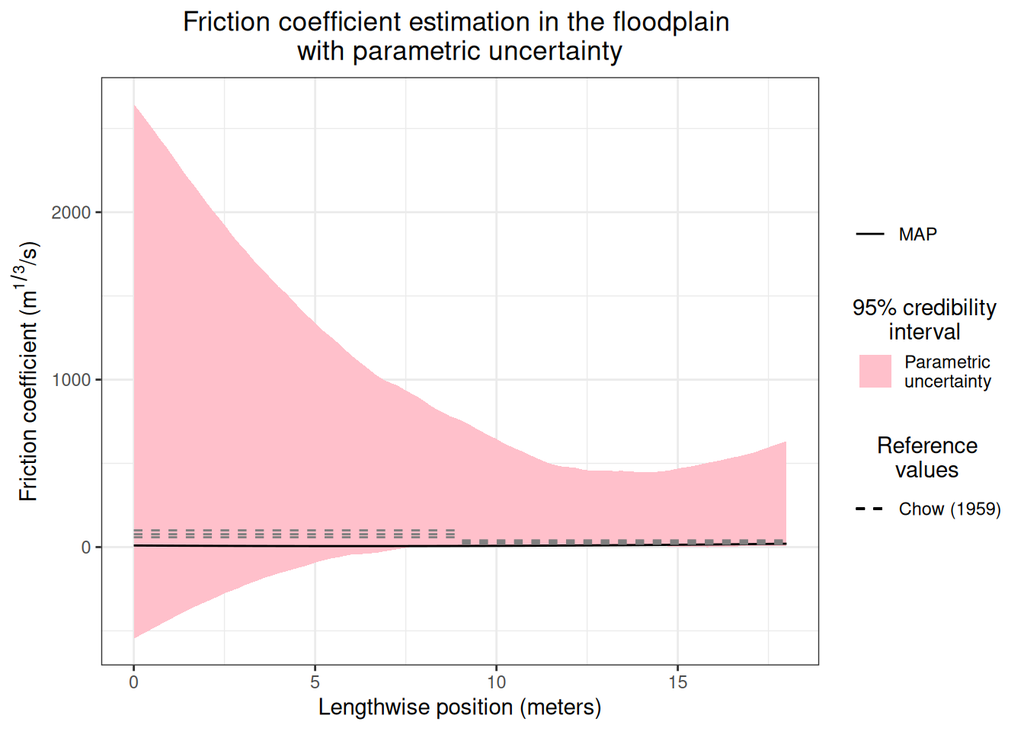

### Partial conclusions:

- The estimated values are not coherent.

## Check of residuals

| event | reach | x | t | WSE | Discharge | Velocity | Y_Kmin | Y_Kmoy | Yu_z | Yu_Q | Yu_V | Yu_Kmin | Yu_Kmoy |
| --- | --- | --- | --- | --- | --- | --- | --- | --- | --- | --- | --- | --- | --- |
| 1 | 1 | 2.225 | 3420 | 0.1949608 | -9999 | -9999 | -9999 | -9999 | 0.0222257 | -9999 | -9999 | -9999 | -9999 |
| 1 | 1 | 4.310 | 3420 | 0.1880788 | -9999 | -9999 | -9999 | -9999 | 0.0222257 | -9999 | -9999 | -9999 | -9999 |
| 1 | 1 | 5.270 | 3420 | 0.1852095 | -9999 | -9999 | -9999 | -9999 | 0.0222257 | -9999 | -9999 | -9999 | -9999 |
| 1 | 1 | 6.240 | 3420 | 0.1829345 | -9999 | -9999 | -9999 | -9999 | 0.0222257 | -9999 | -9999 | -9999 | -9999 |
| 1 | 1 | 8.315 | 3420 | 0.1767361 | -9999 | -9999 | -9999 | -9999 | 0.0222257 | -9999 | -9999 | -9999 | -9999 |
| 1 | 1 | 9.115 | 3420 | 0.1744950 | -9999 | -9999 | -9999 | -9999 | 0.0222257 | -9999 | -9999 | -9999 | -9999 |
| 1 | 1 | 9.250 | 3420 | 0.1744835 | -9999 | -9999 | -9999 | -9999 | 0.0222257 | -9999 | -9999 | -9999 | -9999 |
| 1 | 1 | 10.250 | 3420 | 0.1737731 | -9999 | -9999 | -9999 | -9999 | 0.0222257 | -9999 | -9999 | -9999 | -9999 |
| 1 | 1 | 11.250 | 3420 | 0.1732561 | -9999 | -9999 | -9999 | -9999 | 0.0222257 | -9999 | -9999 | -9999 | -9999 |
| 1 | 1 | 12.250 | 3420 | 0.1728932 | -9999 | -9999 | -9999 | -9999 | 0.0222257 | -9999 | -9999 | -9999 | -9999 |
| 1 | 1 | 13.250 | 3420 | 0.1729610 | -9999 | -9999 | -9999 | -9999 | 0.0222257 | -9999 | -9999 | -9999 | -9999 |
| 2 | 1 | 2.225 | 3420 | 0.1902885 | -9999 | -9999 | -9999 | -9999 | 0.0222257 | -9999 | -9999 | -9999 | -9999 |
| 2 | 1 | 2.975 | 3420 | 0.1911852 | -9999 | -9999 | -9999 | -9999 | 0.0222257 | -9999 | -9999 | -9999 | -9999 |
| 2 | 1 | 3.345 | 3420 | 0.1892610 | -9999 | -9999 | -9999 | -9999 | 0.0222257 | -9999 | -9999 | -9999 | -9999 |
| 2 | 1 | 4.095 | 3420 | 0.1882043 | -9999 | -9999 | -9999 | -9999 | 0.0222257 | -9999 | -9999 | -9999 | -9999 |
| 2 | 1 | 5.060 | 3420 | 0.1864261 | -9999 | -9999 | -9999 | -9999 | 0.0222257 | -9999 | -9999 | -9999 | -9999 |
| 2 | 1 | 6.240 | 3420 | 0.1797323 | -9999 | -9999 | -9999 | -9999 | 0.0222257 | -9999 | -9999 | -9999 | -9999 |
| 2 | 1 | 6.990 | 3420 | 0.1818093 | -9999 | -9999 | -9999 | -9999 | 0.0222257 | -9999 | -9999 | -9999 | -9999 |
| 2 | 1 | 8.030 | 3420 | 0.1790497 | -9999 | -9999 | -9999 | -9999 | 0.0222257 | -9999 | -9999 | -9999 | -9999 |
| 2 | 1 | 8.795 | 3420 | 0.1743624 | -9999 | -9999 | -9999 | -9999 | 0.0222257 | -9999 | -9999 | -9999 | -9999 |
| 2 | 1 | 9.065 | 3420 | 0.1760431 | -9999 | -9999 | -9999 | -9999 | 0.0222257 | -9999 | -9999 | -9999 | -9999 |
| 2 | 1 | 9.115 | 3420 | 0.1721755 | -9999 | -9999 | -9999 | -9999 | 0.0222257 | -9999 | -9999 | -9999 | -9999 |
| 2 | 1 | 9.545 | 3420 | 0.1748087 | -9999 | -9999 | -9999 | -9999 | 0.0222257 | -9999 | -9999 | -9999 | -9999 |
| 2 | 1 | 10.030 | 3420 | 0.1738211 | -9999 | -9999 | -9999 | -9999 | 0.0222257 | -9999 | -9999 | -9999 | -9999 |
| 2 | 1 | 11.370 | 3420 | 0.1701349 | -9999 | -9999 | -9999 | -9999 | 0.0222257 | -9999 | -9999 | -9999 | -9999 |
| 2 | 1 | 12.120 | 3420 | 0.1723571 | -9999 | -9999 | -9999 | -9999 | 0.0222257 | -9999 | -9999 | -9999 | -9999 |
| 2 | 1 | 12.325 | 3420 | 0.1718688 | -9999 | -9999 | -9999 | -9999 | 0.0222257 | -9999 | -9999 | -9999 | -9999 |
| 2 | 1 | 13.290 | 3420 | 0.1715232 | -9999 | -9999 | -9999 | -9999 | 0.0222257 | -9999 | -9999 | -9999 | -9999 |

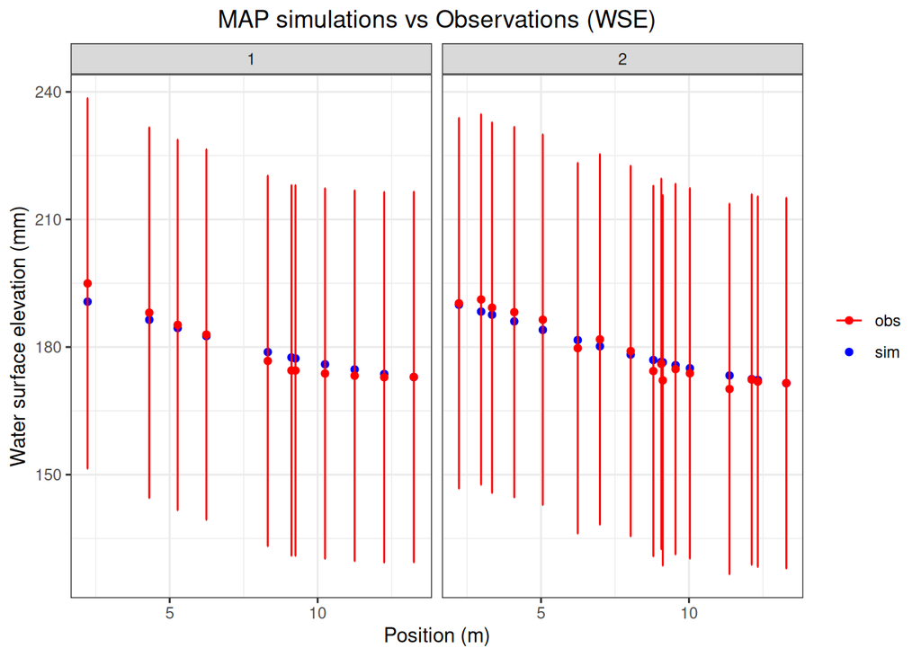

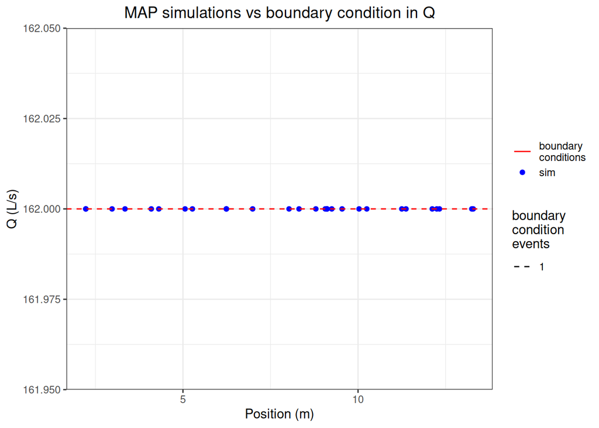

### Partial conclusions:

All simulations of MAP estimation are passing through the observed data with their uncertainty.

# Estimation with lower uncertainty for observations : 8 mm

## Check MCMC

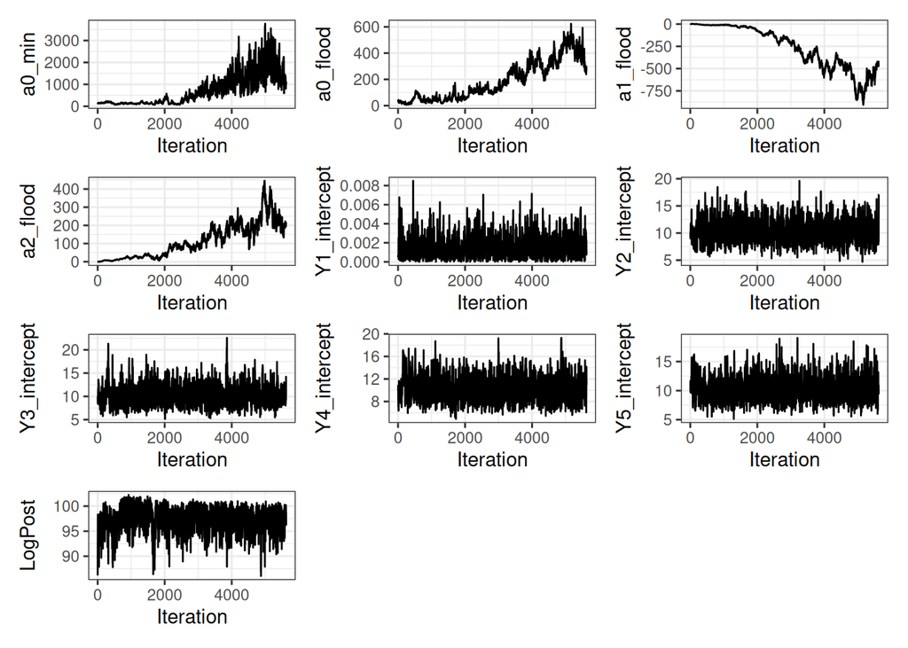

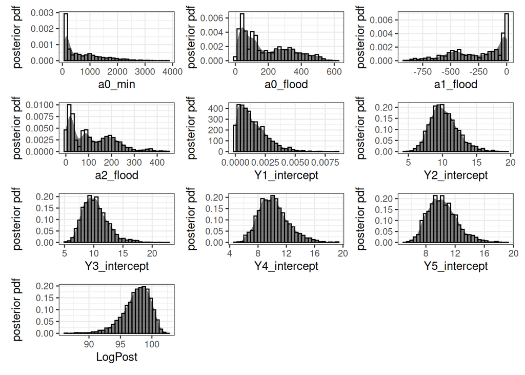

## Check summary

Zoom into the MAP and standard deviation of the error model: WSE in mm, discharge in L/s and velocity in mm/s.

|  | a0_min | a0_flood | a1_flood | a2_flood | Y1_intercept | Y2_intercept | Y3_intercept | Y4_intercept | Y5_intercept |
| --- | --- | --- | --- | --- | --- | --- | --- | --- | --- |
| N | 5.62600e+03 | 5626.000000 | 5626.000000 | 5626.0000000 | 5.62600e+03 | 5626.000000 | 5626.000000 | 5626.000000 | 5626.000000 |
| Minimum | 6.75107e+01 | 6.469160 | -906.062000 | -0.7573170 | 2.20000e-06 | 4.691900 | 5.153310 | 4.907100 | 5.132820 |
| Maximum | 3.76359e+03 | 623.575000 | 3.415800 | 445.0820000 | 8.49710e-03 | 19.618200 | 22.568900 | 19.288500 | 19.072600 |
| Range | 3.69608e+03 | 617.106000 | 909.478000 | 445.8390000 | 8.49490e-03 | 14.926300 | 17.415600 | 14.381400 | 13.939800 |
| Mean | 7.08821e+02 | 184.403000 | -254.284000 | 112.8090000 | 1.45270e-03 | 10.241000 | 10.269800 | 10.210000 | 10.273000 |
| Median | 4.43296e+02 | 127.911000 | -184.112000 | 91.1873000 | 1.14500e-03 | 10.045800 | 10.006700 | 10.031300 | 10.114900 |
| Q10% | 1.13531e+02 | 30.370700 | -592.779000 | 10.0411000 | 2.22500e-04 | 7.826580 | 7.763490 | 7.726840 | 7.853240 |
| Q25% | 1.43163e+02 | 53.332800 | -449.539000 | 24.8515000 | 5.47400e-04 | 8.830190 | 8.689880 | 8.720070 | 8.844560 |
| Q75% | 1.09482e+03 | 299.779000 | -22.523900 | 184.4360000 | 2.12150e-03 | 11.473300 | 11.474700 | 11.395800 | 11.502200 |
| Q90% | 1.77611e+03 | 407.080000 | -9.443910 | 238.5600000 | 3.06040e-03 | 12.887600 | 13.060000 | 13.022800 | 12.874700 |
| St.Dev. | 6.92355e+02 | 145.974000 | 239.004000 | 94.9262000 | 1.16140e-03 | 2.048740 | 2.193510 | 2.120600 | 2.023380 |
| Variance | 4.79356e+05 | 21308.300000 | 57123.100000 | 9010.9800000 | 1.30000e-06 | 4.197320 | 4.811480 | 4.496930 | 4.094050 |
| CV | 9.76770e-01 | 0.791603 | 0.939910 | 0.8414740 | 7.99460e-01 | 0.200052 | 0.213588 | 0.207697 | 0.196961 |
| Skewness | 1.20876e+00 | 0.677851 | -0.617061 | 0.7780830 | 1.22652e+00 | 0.590819 | 0.874968 | 0.665839 | 0.605191 |
| Kurtosis | 8.19305e-01 | -0.728789 | -0.798636 | -0.0533204 | 1.91539e+00 | 0.533511 | 1.382410 | 0.667490 | 0.521433 |
| MaxPost | 1.30432e+02 | 31.930300 | -10.834200 | 22.9262000 | 3.75100e-04 | 9.156150 | 9.644310 | 9.403030 | 10.409300 |

|  | a0_min | a0_flood | a1_flood | a2_flood | Y1_intercept | Y2_intercept | Y3_intercept | Y4_intercept | Y5_intercept |
| --- | --- | --- | --- | --- | --- | --- | --- | --- | --- |
| St.Dev. | 692.355 | 145.9740 | 239.0040 | 94.9262 | 1.161410 | 2048.74 | 219.351 | 2.12060 | 2.02338 |
| MaxPost | 130.432 | 31.9303 | -10.8342 | 22.9262 | 0.375124 | 9156.15 | 964.431 | 9.40303 | 10.40930 |

## Check spatial friction distribution

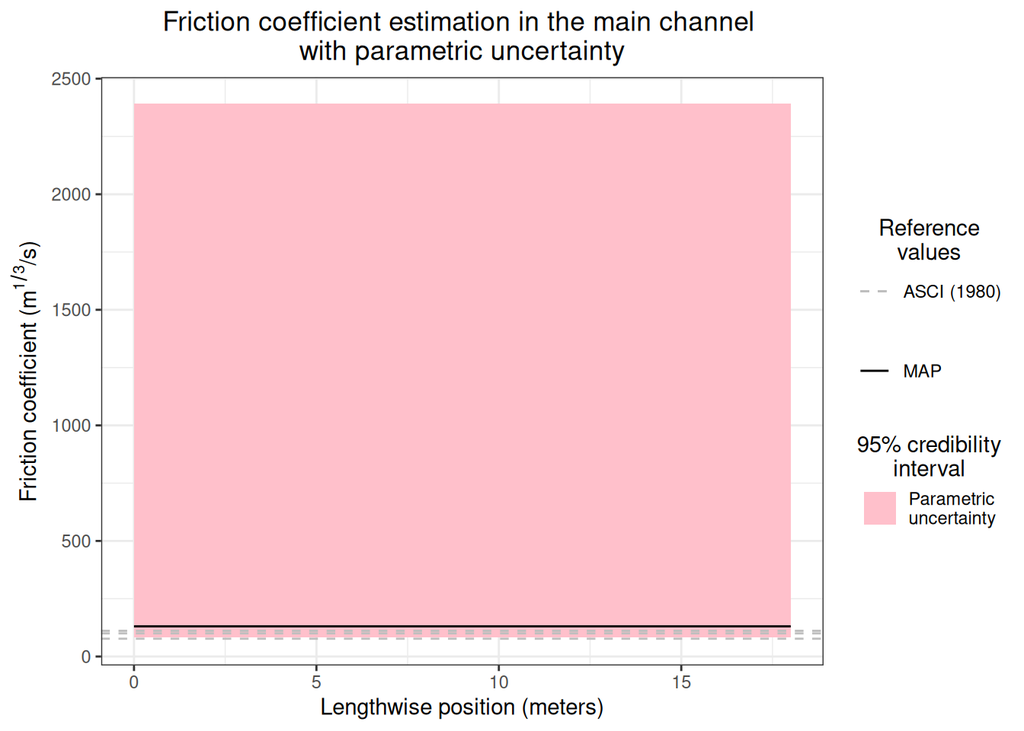

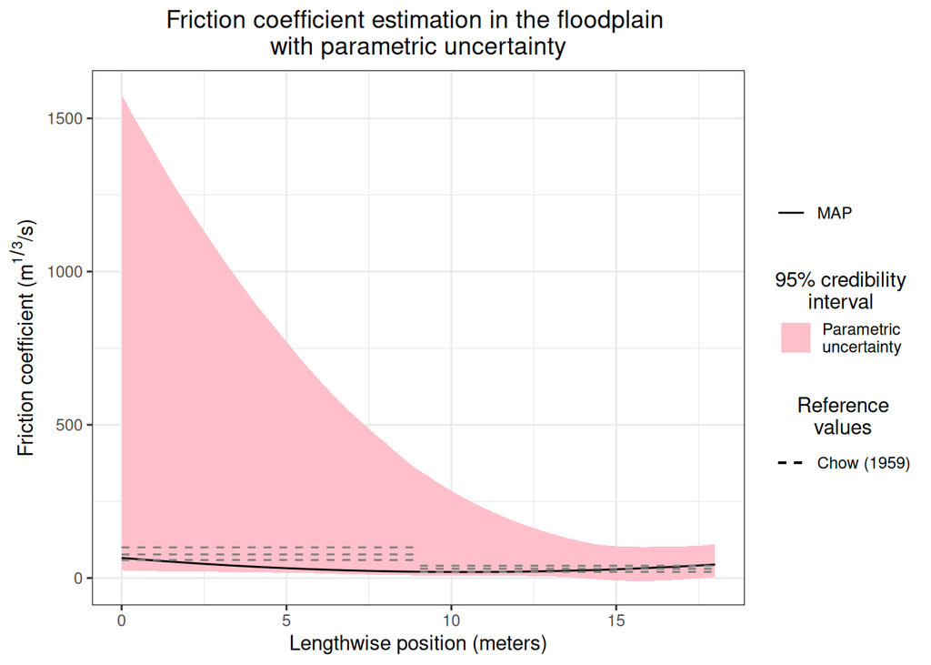

## Check of residuals

| event | reach | x | t | WSE | Discharge | Velocity | Y_Kmin | Y_Kmoy | Yu_z | Yu_Q | Yu_V | Yu_Kmin | Yu_Kmoy |
| --- | --- | --- | --- | --- | --- | --- | --- | --- | --- | --- | --- | --- | --- |
| 1 | 1 | 2.225 | 3420 | 0.1949608 | -9999 | -9999 | -9999 | -9999 | 0.008 | -9999 | -9999 | -9999 | -9999 |
| 1 | 1 | 4.310 | 3420 | 0.1880788 | -9999 | -9999 | -9999 | -9999 | 0.008 | -9999 | -9999 | -9999 | -9999 |
| 1 | 1 | 5.270 | 3420 | 0.1852095 | -9999 | -9999 | -9999 | -9999 | 0.008 | -9999 | -9999 | -9999 | -9999 |
| 1 | 1 | 6.240 | 3420 | 0.1829345 | -9999 | -9999 | -9999 | -9999 | 0.008 | -9999 | -9999 | -9999 | -9999 |
| 1 | 1 | 8.315 | 3420 | 0.1767361 | -9999 | -9999 | -9999 | -9999 | 0.008 | -9999 | -9999 | -9999 | -9999 |
| 1 | 1 | 9.115 | 3420 | 0.1744950 | -9999 | -9999 | -9999 | -9999 | 0.008 | -9999 | -9999 | -9999 | -9999 |
| 1 | 1 | 9.250 | 3420 | 0.1744835 | -9999 | -9999 | -9999 | -9999 | 0.008 | -9999 | -9999 | -9999 | -9999 |
| 1 | 1 | 10.250 | 3420 | 0.1737731 | -9999 | -9999 | -9999 | -9999 | 0.008 | -9999 | -9999 | -9999 | -9999 |
| 1 | 1 | 11.250 | 3420 | 0.1732561 | -9999 | -9999 | -9999 | -9999 | 0.008 | -9999 | -9999 | -9999 | -9999 |
| 1 | 1 | 12.250 | 3420 | 0.1728932 | -9999 | -9999 | -9999 | -9999 | 0.008 | -9999 | -9999 | -9999 | -9999 |
| 1 | 1 | 13.250 | 3420 | 0.1729610 | -9999 | -9999 | -9999 | -9999 | 0.008 | -9999 | -9999 | -9999 | -9999 |
| 2 | 1 | 2.225 | 3420 | 0.1902885 | -9999 | -9999 | -9999 | -9999 | 0.008 | -9999 | -9999 | -9999 | -9999 |
| 2 | 1 | 2.975 | 3420 | 0.1911852 | -9999 | -9999 | -9999 | -9999 | 0.008 | -9999 | -9999 | -9999 | -9999 |
| 2 | 1 | 3.345 | 3420 | 0.1892610 | -9999 | -9999 | -9999 | -9999 | 0.008 | -9999 | -9999 | -9999 | -9999 |
| 2 | 1 | 4.095 | 3420 | 0.1882043 | -9999 | -9999 | -9999 | -9999 | 0.008 | -9999 | -9999 | -9999 | -9999 |
| 2 | 1 | 5.060 | 3420 | 0.1864261 | -9999 | -9999 | -9999 | -9999 | 0.008 | -9999 | -9999 | -9999 | -9999 |
| 2 | 1 | 6.240 | 3420 | 0.1797323 | -9999 | -9999 | -9999 | -9999 | 0.008 | -9999 | -9999 | -9999 | -9999 |
| 2 | 1 | 6.990 | 3420 | 0.1818093 | -9999 | -9999 | -9999 | -9999 | 0.008 | -9999 | -9999 | -9999 | -9999 |
| 2 | 1 | 8.030 | 3420 | 0.1790497 | -9999 | -9999 | -9999 | -9999 | 0.008 | -9999 | -9999 | -9999 | -9999 |
| 2 | 1 | 8.795 | 3420 | 0.1743624 | -9999 | -9999 | -9999 | -9999 | 0.008 | -9999 | -9999 | -9999 | -9999 |
| 2 | 1 | 9.065 | 3420 | 0.1760431 | -9999 | -9999 | -9999 | -9999 | 0.008 | -9999 | -9999 | -9999 | -9999 |
| 2 | 1 | 9.115 | 3420 | 0.1721755 | -9999 | -9999 | -9999 | -9999 | 0.008 | -9999 | -9999 | -9999 | -9999 |
| 2 | 1 | 9.545 | 3420 | 0.1748087 | -9999 | -9999 | -9999 | -9999 | 0.008 | -9999 | -9999 | -9999 | -9999 |
| 2 | 1 | 10.030 | 3420 | 0.1738211 | -9999 | -9999 | -9999 | -9999 | 0.008 | -9999 | -9999 | -9999 | -9999 |
| 2 | 1 | 11.370 | 3420 | 0.1701349 | -9999 | -9999 | -9999 | -9999 | 0.008 | -9999 | -9999 | -9999 | -9999 |
| 2 | 1 | 12.120 | 3420 | 0.1723571 | -9999 | -9999 | -9999 | -9999 | 0.008 | -9999 | -9999 | -9999 | -9999 |
| 2 | 1 | 12.325 | 3420 | 0.1718688 | -9999 | -9999 | -9999 | -9999 | 0.008 | -9999 | -9999 | -9999 | -9999 |
| 2 | 1 | 13.290 | 3420 | 0.1715232 | -9999 | -9999 | -9999 | -9999 | 0.008 | -9999 | -9999 | -9999 | -9999 |

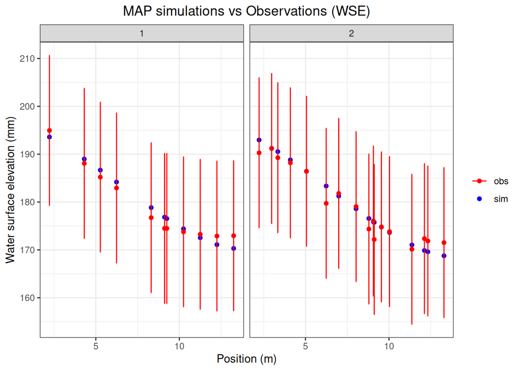

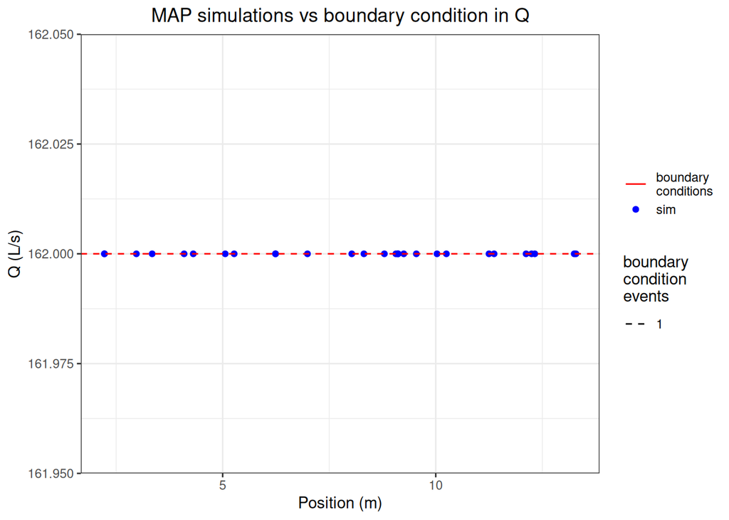

## Main conclusions:

- Thee streamwise distance as covariant to spatial distribute the friction coefficient is not enough to estimate the friction coefficient when the roughness changes suddenly. Changes are modelized smoothly, but the real-world conditions are not.

# Bibliography:

Dupuis, Victor, Sébastien Proust, Céline Berni, and André Paquier. 2017. “Compound Channel Flow with a Longitudinal Transition in Hydraulic Roughness over the Floodplains.” *Environmental Fluid Mechanics* 17 (5): 903–28. https://doi.org/10.1007/s10652-017-9525-0.